# DS_Assignment_06

Ankit

21/11/2021

```r
library(tidyverse) #loading,library
```

## 1.

### 1.1

```r
boston <- read.delim('boston.csv.bz2')  # loading dataset
head(boston)
```

```
##      crim zn indus chas   nox    rm  age    dis rad tax ptratio  black lstat
## 1 0.00632 18  2.31    0 0.538 6.575 65.2 4.0900   1 296    15.3 396.90  4.98
## 2 0.02731  0  7.07    0 0.469 6.421 78.9 4.9671   2 242    17.8 396.90  9.14
## 3 0.02729  0  7.07    0 0.469 7.185 61.1 4.9671   2 242    17.8 392.83  4.03
## 4 0.03237  0  2.18    0 0.458 6.998 45.8 6.0622   3 222    18.7 394.63  2.94
## 5 0.06905  0  2.18    0 0.458 7.147 54.2 6.0622   3 222    18.7 396.90  5.33
## 6 0.02985  0  2.18    0 0.458 6.430 58.7 6.0622   3 222    18.7 394.12  5.21
##   medv
## 1 24.0
## 2 21.6
## 3 34.7
## 4 33.4
## 5 36.2
## 6 28.7
```

```r
summary(boston) #summary
```

```
##       crim                zn             indus            chas
##  Min.   : 0.00632   Min.   :  0.00   Min.   : 0.46   Min.   :0.00000
##  1st Qu.: 0.08205   1st Qu.:  0.00   1st Qu.: 5.19   1st Qu.:0.00000
##  Median : 0.25651   Median :  0.00   Median : 9.69   Median :0.00000
##  Mean   : 3.61352   Mean   : 11.36   Mean   :11.14   Mean   :0.06917
##  3rd Qu.: 3.67708   3rd Qu.: 12.50   3rd Qu.:18.10   3rd Qu.:0.00000
##  Max.   :88.97620   Max.   :100.00   Max.   :27.74   Max.   :1.00000
##       nox               rm             age              dis
##  Min.   :0.3850   Min.   :3.561   Min.   :  2.90   Min.   : 1.130
##  1st Qu.:0.4490   1st Qu.:5.886   1st Qu.: 45.02   1st Qu.: 2.100
##  Median :0.5380   Median :6.208   Median : 77.50   Median : 3.207
##  Mean   :0.5547   Mean   :6.285   Mean   : 68.57   Mean   : 3.795
##  3rd Qu.:0.6240   3rd Qu.:6.623   3rd Qu.: 94.08   3rd Qu.: 5.188
##  Max.   :0.8710   Max.   :8.780   Max.   :100.00   Max.   :12.127
##       rad              tax           ptratio          black
##  Min.   : 1.000   Min.   :187.0   Min.   :12.60   Min.   :  0.32
##  1st Qu.: 4.000   1st Qu.:279.0   1st Qu.:17.40   1st Qu.:375.38
##  Median : 5.000   Median :330.0   Median :19.05   Median :391.44
##  Mean   : 9.549   Mean   :408.2   Mean   :18.46   Mean   :356.67
##  3rd Qu.:24.000   3rd Qu.:666.0   3rd Qu.:20.20   3rd Qu.:396.23
##  Max.   :24.000   Max.   :711.0   Max.   :22.00   Max.   :396.90
##      lstat            medv
##  Min.   : 1.73   Min.   : 5.00
##  1st Qu.: 6.95   1st Qu.:17.02
##  Median :11.36   Median :21.20
##  Mean   :12.65   Mean   :22.53
##  3rd Qu.:16.95   3rd Qu.:25.00
##  Max.   :37.97   Max.   :50.00
```

```r
dim(boston)  #dimensions
```

```
## [1] 506  14
```

```r
sum(is.na(boston))  #missing
```

```
## [1] 0
```

### 1.2

#### 1.2(a)

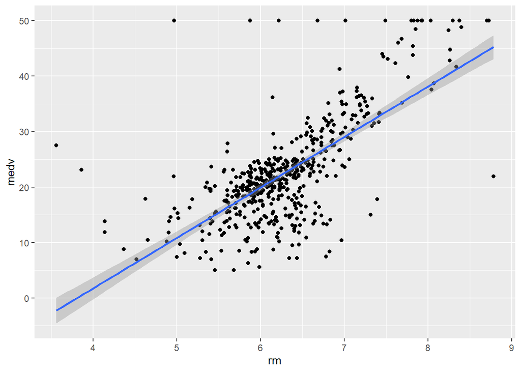

```r
ggplot(boston, aes(rm,medv)) +
  geom_point() +
  geom_smooth(method="lm")  # scatter plot of rm vs medv
```

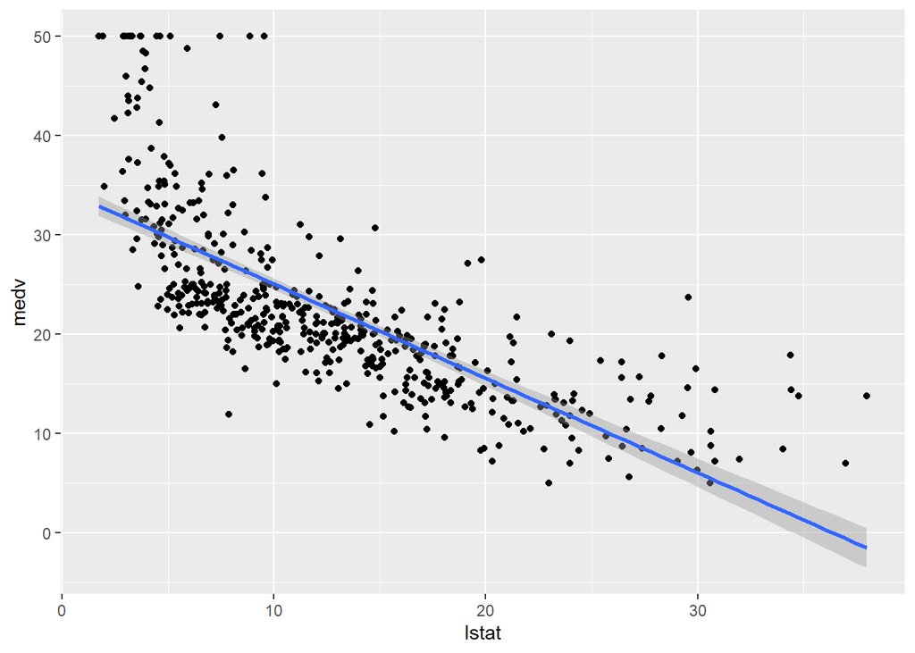

```r
ggplot(boston, aes(lstat, medv)) +
  geom_point() +
  geom_smooth(method="lm")  # scatter plot of lstat vs medv
```

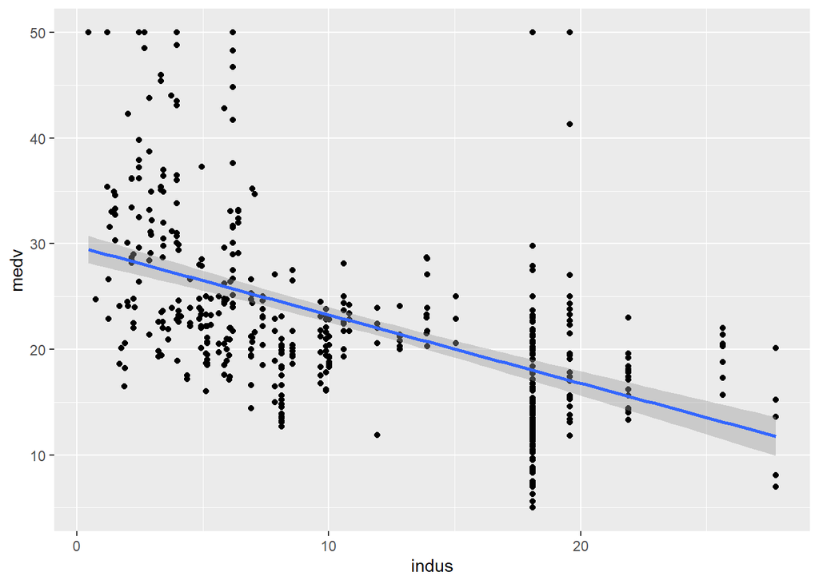

```r
ggplot(boston, aes(indus, medv)) +
  geom_point() +
  geom_smooth(method="lm")  # scatter plot of indus vs medv
```

Comment the result:

We can see from the the graph of rm, it is showing positive association with the medv whereas lstat and indus is showing negatively association with the medv.

### 1.2(b)

```r
summary(m <- lm(medv ~ rm, data=boston)) # model for rm variable
```

```
##
## Call:
## lm(formula = medv ~ rm, data = boston)
##
## Residuals:
##     Min      1Q  Median      3Q     Max
## -23.346  -2.547   0.090   2.986  39.433
##
## Coefficients:
##             Estimate Std. Error t value Pr(>|t|)
## (Intercept)  -34.671      2.650  -13.08   <2e-16 ***
## rm             9.102      0.419   21.72   <2e-16 ***
## ---
## Signif. codes:  0 '***' 0.001 '**' 0.01 '*' 0.05 '.' 0.1 ' ' 1
##
## Residual standard error: 6.616 on 504 degrees of freedom
## Multiple R-squared:  0.4835, Adjusted R-squared:  0.4825
## F-statistic: 471.8 on 1 and 504 DF,  p-value: < 2.2e-16
```

```r
summary(m <- lm(medv ~ lstat, data=boston))  # model for lstat variable
```

```
##
## Call:
## lm(formula = medv ~ lstat, data = boston)
##
## Residuals:
##     Min      1Q  Median      3Q     Max
## -15.168  -3.990  -1.318   2.034  24.500
##
## Coefficients:
##             Estimate Std. Error t value Pr(>|t|)
## (Intercept) 34.55384    0.56263   61.41   <2e-16 ***
## lstat       -0.95005    0.03873  -24.53   <2e-16 ***
## ---
## Signif. codes:  0 '***' 0.001 '**' 0.01 '*' 0.05 '.' 0.1 ' ' 1
##
## Residual standard error: 6.216 on 504 degrees of freedom
## Multiple R-squared:  0.5441, Adjusted R-squared:  0.5432
## F-statistic: 601.6 on 1 and 504 DF,  p-value: < 2.2e-16
```

```r
summary(m <- lm(medv ~ indus, data=boston))  #model for indus variable
```

```
##
## Call:
## lm(formula = medv ~ indus, data = boston)
##
## Residuals:
##     Min      1Q  Median      3Q     Max
## -13.017  -4.917  -1.457   3.180  32.943
##
## Coefficients:
##             Estimate Std. Error t value Pr(>|t|)
## (Intercept) 29.75490    0.68345   43.54   <2e-16 ***
## indus       -0.64849    0.05226  -12.41   <2e-16 ***
## ---
## Signif. codes:  0 '***' 0.001 '**' 0.01 '*' 0.05 '.' 0.1 ' ' 1
##
## Residual standard error: 8.057 on 504 degrees of freedom
## Multiple R-squared:  0.234,  Adjusted R-squared:  0.2325
## F-statistic:   154 on 1 and 504 DF,  p-value: < 2.2e-16
```

### 1.2(c)

For rm, it is statistically significant (p value is less than 0.05 which lies within 5% CI). Also, as we increase 1 unit of rm it will increase 9.102 units of medv.

For lstat, it is statistically significant (p value is less than 0.05 which lies within 5% CI). As we increase 1 unit of lstat it will decrease -0.95 units of medv.

For indus, it is statistically significant (p value is less than 0.05 which lies within 5% CI). As we increase 1 unit of indus it will decrease -0.64 units of medv.

### 1.2(d)

For rm, as the average number of rooms per dwelling increases, the cost of the apartment is also supposed to increase which suggests that people in the neighbourhood are wealthy as they are able to afford expensive apartemtns which suggests that the whole neighbourhood expensive (suggested by the graph also, as the number of room is inreasing the medv is also increasing).

For lstat, the prices of the the houses would be low where the lower status poppulation is living which suggests that the neighbourhood is not wealthy moreover to a lower background. Another point is as they cannot afford expensive houses. This can be seen from the graph that as the lstat is increase medv is decreasing.

For indus which is neighbourhood with mostly non retail business suggests us two things:

1. The neighbourhood has a lot of manufacturing factories, which suggests that there are no/less houses and as there are less houses the value of the houses are also very less(cheap) which is exactly what the graph suggests us as the non retail business increases the medv would decrease.
2. If the neighbourhood doesn’t have retail businesses, people would not want to live there as daily use items won’t be available easaily which means that it will be difficult for the people in neighborhood to buy groceries and other stuff. So, why would anyone wants to live in such a place unless the person is not rich. Hence this suggests that the neighbourhood is with people who are not earning much so is the plot.

### 1.3

Yes, the relationship suggested by the plot is related to the model which is statistically significant. As we can see from the the graph of rm, it is showing positive association with the medv and from the model also we can see that rm is statistically significant and in positive relationship with medv.

Similarly for lstat, we can see from the graph that lstat is negatively associated with the medv and same is the case with the model. Model is statistically significant and negative relationship with medv.

### 1.4

T value computed by the formula -> estimate/standard error. The null hypotheses(H0) here is that mdev is not assocaited with rm.

To calculate t critical value, we have to use t distribution table at 95% confidence interval and two tail test. Our degree of freedom isi 504 and two tail value in 0.05, so out t critical is 1.962.

### 1.5

```r
summary(m <- lm(medv ~ ., data=boston))
```

```
##
## Call:
## lm(formula = medv ~ ., data = boston)
##
## Residuals:
##     Min      1Q  Median      3Q     Max
## -15.595  -2.730  -0.518   1.777  26.199
##
## Coefficients:
##               Estimate Std. Error t value Pr(>|t|)
## (Intercept)  3.646e+01  5.103e+00   7.144 3.28e-12 ***
## crim        -1.080e-01  3.286e-02  -3.287 0.001087 **
## zn           4.642e-02  1.373e-02   3.382 0.000778 ***
## indus        2.056e-02  6.150e-02   0.334 0.738288
## chas         2.687e+00  8.616e-01   3.118 0.001925 **
## nox         -1.777e+01  3.820e+00  -4.651 4.25e-06 ***
## rm           3.810e+00  4.179e-01   9.116  < 2e-16 ***
## age          6.922e-04  1.321e-02   0.052 0.958229
## dis         -1.476e+00  1.995e-01  -7.398 6.01e-13 ***
## rad          3.060e-01  6.635e-02   4.613 5.07e-06 ***
## tax         -1.233e-02  3.760e-03  -3.280 0.001112 **
## ptratio     -9.527e-01  1.308e-01  -7.283 1.31e-12 ***
## black        9.312e-03  2.686e-03   3.467 0.000573 ***
## lstat       -5.248e-01  5.072e-02 -10.347  < 2e-16 ***
## ---
## Signif. codes:  0 '***' 0.001 '**' 0.01 '*' 0.05 '.' 0.1 ' ' 1
##
## Residual standard error: 4.745 on 492 degrees of freedom
## Multiple R-squared:  0.7406, Adjusted R-squared:  0.7338
## F-statistic: 108.1 on 13 and 492 DF,  p-value: < 2.2e-16
```

As we can see from the above summary, except two variables, all the other variables are statistically significant. Two variables are indus and age.

Except indus and age, we will reject all the other variables.

### 1.6

For rm, rm is statistically significant as we can see that its p value is less than 0.05 which lies in 5% confidence interval.

For lstat, similarly for lstat, it is statistically significant as we can see that its p value is less than 0.05 which lies in 5% confidence interval.

For indus, it is not statistically significant as we can see that its p value is more than 0.05 which doesn’t lie in 5% confidence interval.

### 1.7

If we compare the results from 2 and 5:

For rm, t value in question 2 is 21.72 and in question 5 it is 9.116. They are different because of direct and indirect relationships between rm and medv. In simple regression, rm and medv are in direct relationship but there are other indirect relationships between other variables and medv and rm. Whereas in the case of question 5, becaue multiple variables are exerting direct relationships with the medv which is neglecting indirect relationships between multiple variables and rm.

Similarly for lstat, in question 2 the t value is -24.53 and in question 5 - 10.347. The difference in the number is also because of the effect of direct and indirect relationship.

Also, for indus because of the effect of indirect and direct realtion there is difference between question 2 (-12.41) and question 5 (0.334) and if we notice, indus is no more statistically significant in question 5.

## 2.

### 2.1

Number of evictions is positively associated with the 311 calls. More evictions see more 311 calls. One unit increase no. of evictions is 0.04 units of increase in calls.

### 2.3

Poverty rate is negatively associated with the 311 calls. 1 unit increase in poverty rate leads to -0.14 unit decrease in 311 calls.

### 2.6

The value of housing density is -0.13. It means that one unit increase of housing density will leads to 0.13 units decrease in the 311 calls (because it is negative it will eventually be decreasing).

### 2.7

The omitted category for city is Austin, TX is an reference category. To compare it with the neighbourhood of Philadelphia, it has less calls by 0.56 unit.

## 3.

### 3.1

Number of evictions is positively associated with the 311 calls. More evictions see more 311 calls. One percent increase no. of evictions is 0.4 percent of increase in calls.

### 3.3

Poverty rate is negatively associated with the 311 calls. 1 unit increase in poverty rate leads to -1.4% decrease in 311 calls.

### 3.6

The value of housing density is -0.13. It means that one percent increase in housing density will leads to 1.3% decreasae in the 311 calls (because it is negative it will eventually be decreasing).

### 3.7

The omitted category for city is Austin, TX is an reference category. To compare it with the neighbourhood of Philadelphia, it has less calls by -0.56 units.